# Análisis de color

## Juan Manuel González Ascencio - A00572003

```python
#!pip3 install altair
```

```python
import pandas as pd
import altair as alt
import matplotlib.pyplot as plt
import matplotlib.patches as patches
```

```python
# Load the data
df = pd.read_csv('EjemploData.csv', encoding='unicode_escape')
df.head()
```

|  | Order ID | Segment | City | Region | Category | Sub-Category | Product Name | Sales | Quantity | Discount | Profit |
| --- | --- | --- | --- | --- | --- | --- | --- | --- | --- | --- | --- |
| 0 | US-2016-118983 | Home Office | Fort Worth | Central | Office Supplies | Appliances | Holmes Replacement Filter for HEPA Air Cleaner... | 68.810 | 5 | 0.8 | -123.8580 |
| 1 | US-2016-118983 | Home Office | Fort Worth | Central | Office Supplies | Binders | Storex DuraTech Recycled Plastic Frosted Binders | 2.544 | 3 | 0.8 | -3.8160 |
| 2 | CA-2015-105893 | Consumer | Madison | Central | Office Supplies | Storage | Stur-D-Stor Shelving, Vertical 5-Shelf: 72"H x... | 665.880 | 6 | 0.0 | 13.3176 |
| 3 | CA-2017-137330 | Corporate | Fremont | Central | Office Supplies | Art | Newell 318 | 19.460 | 7 | 0.0 | 5.0596 |
| 4 | CA-2017-137330 | Corporate | Fremont | Central | Office Supplies | Appliances | Acco Six-Outlet Power Strip, 4' Cord Length | 60.340 | 7 | 0.0 | 15.6884 |

# Diseño del estilo y paleta de colores

## Logo Elektra

La empresa que me tocó analizar es Electra, la cual es conocida por sus colores amarillos y rojos agresivos.

La paleta de color que posee es la siguiente.

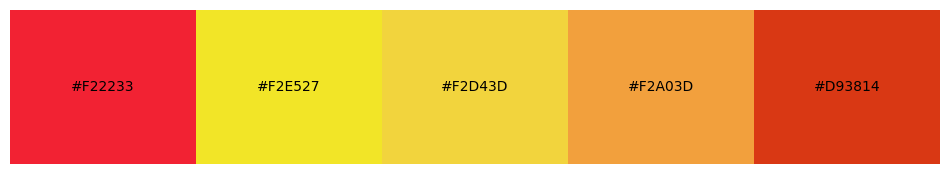

```python
colors = ["#F22233", "#F2E527", "#F2D43D", "#F2A03D", "#D93814"]

#graficamos para mostra la paleta
fig, ax = plt.subplots(figsize=(12, 2))

# Crear rectángulos de color
for i, color in enumerate(colors):
   rect = patches.Rectangle((i, 0), 1, 1, linewidth=1, edgecolor='none', facecolor=color)
   ax.add_patch(rect)
   #Ponemos el nombre del color
   ax.text(i+0.5, 0.5, color, ha='center', va='center', color='black')

ax.set_xlim(0, len(colors))
ax.set_ylim(0, 1)
ax.axis('off')

plt.show()
```

La paleta de colores del logo de Elektra, que incluye tonos vibrantes de rojo, amarillo y naranja, está diseñada para captar la atención y evocar emociones de energía, entusiasmo y dinamismo. El rojo dominante sugiere pasión y urgencia, ideal para atraer clientes y destacar en el mercado. Los tonos amarillos añaden una sensación de optimismo y positividad, mientras que el naranja combina la energía del rojo y la alegría del amarillo, creando una paleta equilibrada que transmite una imagen vibrante y acogedora. Esta combinación de colores no solo es visualmente atractiva, sino que también refuerza la identidad de Elektra como una marca enérgica y confiable.

## Monocromático

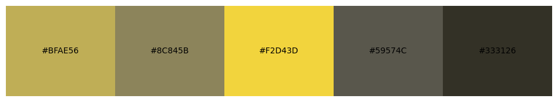

```python
colors = ["#BFAE56", "#8C845B", "#F2D43D", "#59574C", "#333126"]

#graficamos para mostra la paleta
fig, ax = plt.subplots(figsize=(12, 2))

# Crear rectángulos de color
for i, color in enumerate(colors):
   rect = patches.Rectangle((i, 0), 1, 1, linewidth=1, edgecolor='none', facecolor=color)
   ax.add_patch(rect)
   #Ponemos el nombre del color
   ax.text(i+0.5, 0.5, color, ha='center', va='center', color='black')

ax.set_xlim(0, len(colors))
ax.set_ylim(0, 1)
ax.axis('off')

plt.show()
```

La versión monocromática de la paleta de Elektra, compuesta por tonos de dorado, marrón, beige y gris, ofrece una interpretación más sutil y sofisticada de la identidad de la marca. Estos colores aportan una sensación de estabilidad, seriedad y elegancia. El dorado sugiere calidad y valor, mientras que los tonos marrones y grises añaden una atmósfera de confianza y profesionalismo. Esta paleta monocromática, aunque menos llamativa que la original, mantiene un enfoque visual coherente y puede ser utilizada para transmitir una imagen de solidez y madurez, ideal para comunicaciones corporativas y materiales de branding que requieran un toque más refinado.

## Triada

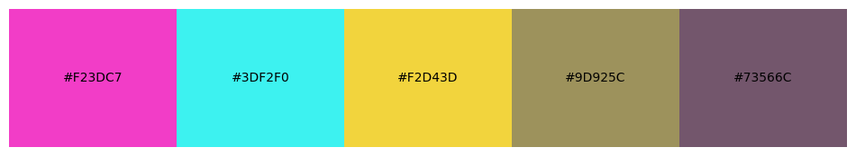

```python
colors = ["#F23DC7", "#3DF2F0", "#F2D43D", "#9D925C", "#73566C"]

#graficamos para mostra la paleta
fig, ax = plt.subplots(figsize=(12, 2))

# Crear rectángulos de color
for i, color in enumerate(colors):
   rect = patches.Rectangle((i, 0), 1, 1, linewidth=1, edgecolor='none', facecolor=color)
   ax.add_patch(rect)
   #Ponemos el nombre del color
   ax.text(i+0.5, 0.5, color, ha='center', va='center', color='black')

ax.set_xlim(0, len(colors))
ax.set_ylim(0, 1)
ax.axis('off')

plt.show()
```

La versión de la paleta de colores en triada para el logo de Elektra, que incluye tonos de rosa, turquesa, dorado, beige y púrpura, ofrece una combinación vibrante y equilibrada que sugiere creatividad y diversidad. El rosa y el turquesa aportan una sensación de frescura y modernidad, infundiendo la marca con dinamismo y atractivo visual. El dorado mantiene una conexión con la calidad y el valor, mientras que el beige y el púrpura añaden profundidad y sofisticación. Esta paleta de triada crea una identidad visual rica y diversa, ideal para destacar en el mercado y atraer a una audiencia variada con un enfoque innovador y vibrante.

## Complementarios

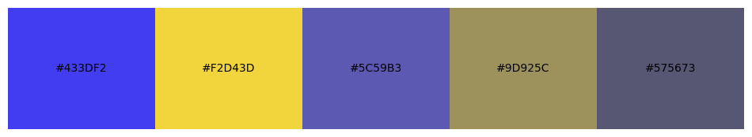

```python
colors = ["#433DF2", "#F2D43D","#5C59B3", "#9D925C", "#575673"]

#graficamos para mostra la paleta
fig, ax = plt.subplots(figsize=(12, 2))

# Crear rectángulos de color
for i, color in enumerate(colors):
   rect = patches.Rectangle((i, 0), 1, 1, linewidth=1, edgecolor='none', facecolor=color)
   ax.add_patch(rect)
   #Ponemos el nombre del color
   ax.text(i+0.5, 0.5, color, ha='center', va='center', color='black')

ax.set_xlim(0, len(colors))
ax.set_ylim(0, 1)
ax.axis('off')

plt.show()
```

La versión complementaria de la paleta de colores del logo de Elektra, que incluye tonos de azul, dorado, púrpura, beige y gris, ofrece un equilibrio dinámico y sofisticado que capta la atención y sugiere diversidad y modernidad. El azul y el dorado, siendo colores complementarios, crean un contraste visual fuerte y atractivo. El azul representa confianza y estabilidad, mientras que el dorado sugiere calidad y valor. Los tonos púrpura y beige añaden profundidad y refinamiento, mientras que el gris proporciona un toque de neutralidad y equilibrio. Esta paleta de colores complementarios destaca por su capacidad para combinar energía y elegancia, transmitiendo una imagen de marca que es tanto vibrante como confiable.

## Análogos

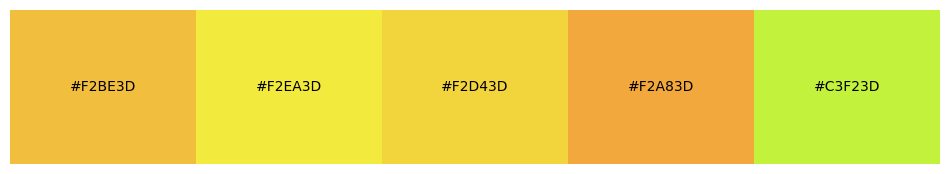

```python
colors = ["#F2BE3D", "#F2EA3D","#F2D43D", "#F2A83D", "#C3F23D"]

#graficamos para mostra la paleta
fig, ax = plt.subplots(figsize=(12, 2))

# Crear rectángulos de color
for i, color in enumerate(colors):
   rect = patches.Rectangle((i, 0), 1, 1, linewidth=1, edgecolor='none', facecolor=color)
   ax.add_patch(rect)
   #Ponemos el nombre del color
   ax.text(i+0.5, 0.5, color, ha='center', va='center', color='black')

ax.set_xlim(0, len(colors))
ax.set_ylim(0, 1)
ax.axis('off')

plt.show()
```

La versión análoga de la paleta de colores del logo de Elektra, que incluye tonos de dorado, amarillo, naranja y verde lima, crea una armonía visual cálida y acogedora. Los colores análogos, que están próximos entre sí en la rueda de colores, ofrecen una transición suave y coherente que transmite una sensación de estabilidad y confort. El dorado y el amarillo sugieren optimismo, energía y claridad, mientras que el naranja aporta calidez y entusiasmo. El verde lima añade un toque de frescura y vitalidad. Esta paleta análoga es ideal para transmitir una imagen de marca vibrante y amigable, enfatizando cualidades de positivismo y accesibilidad.

## Cuadrados

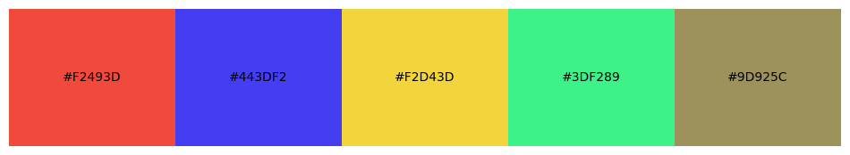

```python
colors = ["#F2493D", "#443DF2","#F2D43D", "#3DF289", "#9D925C"]

#graficamos para mostra la paleta
fig, ax = plt.subplots(figsize=(12, 2))

# Crear rectángulos de color
for i, color in enumerate(colors):
   rect = patches.Rectangle((i, 0), 1, 1, linewidth=1, edgecolor='none', facecolor=color)
   ax.add_patch(rect)
   #Ponemos el nombre del color
   ax.text(i+0.5, 0.5, color, ha='center', va='center', color='black')

ax.set_xlim(0, len(colors))
ax.set_ylim(0, 1)
ax.axis('off')

plt.show()
```

La versión en cuadrado de la paleta de colores del logo de Elektra, que incluye tonos de rojo, azul, dorado, verde y beige, ofrece una combinación vibrante y equilibrada que crea un impacto visual fuerte. El rojo aporta energía y urgencia, el azul representa confianza y estabilidad, el dorado sugiere calidad y valor, el verde transmite frescura y vitalidad, y el beige proporciona un toque de neutralidad y sofisticación. Esta paleta de colores en cuadrado, al utilizar colores equidistantes en la rueda cromática, asegura un equilibrio dinámico y diverso, ideal para destacar la identidad de Elektra como una marca versátil, confiable y llena de vida.

## Tonos

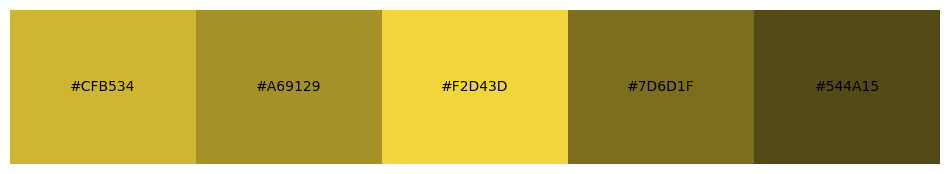

```python
colors = ["#CFB534", "#A69129","#F2D43D", "#7D6D1F", "#544A15"]

#graficamos para mostra la paleta
fig, ax = plt.subplots(figsize=(12, 2))

# Crear rectángulos de color
for i, color in enumerate(colors):
   rect = patches.Rectangle((i, 0), 1, 1, linewidth=1, edgecolor='none', facecolor=color)
   ax.add_patch(rect)
   #Ponemos el nombre del color
   ax.text(i+0.5, 0.5, color, ha='center', va='center', color='black')

ax.set_xlim(0, len(colors))
ax.set_ylim(0, 1)
ax.axis('off')

plt.show()
```

La versión en tonos de la paleta de colores del logo de Elektra, que incluye varios matices de dorado y marrón, ofrece una interpretación más sutil y sofisticada de la identidad de la marca. Los distintos tonos de dorado, desde el brillante hasta el más oscuro, sugieren calidad, valor y tradición, mientras que los marrones añaden una sensación de estabilidad, fiabilidad y calidez. Esta paleta tonal crea una imagen de marca que es coherente y elegante, ideal para transmitir una sensación de madurez y solidez, manteniendo al mismo tiempo un aspecto atractivo y profesional.

## Compuestos

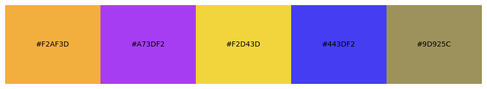

```python
colors = ["#F2AF3D", "#A73DF2","#F2D43D", "#443DF2", "#9D925C"]

#graficamos para mostra la paleta
fig, ax = plt.subplots(figsize=(12, 2))

# Crear rectángulos de color
for i, color in enumerate(colors):
   rect = patches.Rectangle((i, 0), 1, 1, linewidth=1, edgecolor='none', facecolor=color)
   ax.add_patch(rect)
   #Ponemos el nombre del color
   ax.text(i+0.5, 0.5, color, ha='center', va='center', color='black')

ax.set_xlim(0, len(colors))
ax.set_ylim(0, 1)
ax.axis('off')

plt.show()
```

La versión compuesta de la paleta de colores del logo de Elektra, que incluye tonos de naranja, púrpura, dorado, azul y beige, ofrece una combinación vibrante y armoniosa que equilibra contraste y coherencia. El naranja aporta energía y entusiasmo, el púrpura sugiere creatividad y lujo, el dorado simboliza calidad y valor, el azul representa confianza y estabilidad, mientras que el beige añade un toque de neutralidad y sofisticación. Esta paleta compuesta, al combinar colores opuestos y adyacentes en la rueda cromática, crea una imagen visualmente rica y atractiva, ideal para destacar la diversidad y dinamismo de la marca Elektra, manteniendo una sensación de cohesión y equilibrio.

# Gráficas

```python
#Paletas de colores
logo = ["#F22233", "#F2E527", "#F2D43D", "#F2A03D", "#D93814"]
monocromatico = ["#BFAE56", "#8C845B", "#F2D43D", "#59574C", "#333126"]
triada = ["#F23DC7", "#3DF2F0", "#F2D43D", "#9D925C", "#73566C"]
complementarios = ["#433DF2", "#F2D43D","#5C59B3", "#9D925C", "#575673"]
analogos = ["#F2BE3D", "#F2EA3D","#F2D43D", "#F2A83D", "#C3F23D"]
cuadrados = ["#F2493D", "#443DF2","#F2D43D", "#3DF289", "#9D925C"]
tonos = ["#CFB534", "#A69129","#F2D43D", "#7D6D1F", "#544A15"]
compuestos = ["#F2AF3D", "#A73DF2","#F2D43D", "#443DF2", "#9D925C"]
```

```python
df.head(2)
```

|  | Order ID | Segment | City | Region | Category | Sub-Category | Product Name | Sales | Quantity | Discount | Profit |
| --- | --- | --- | --- | --- | --- | --- | --- | --- | --- | --- | --- |
| 0 | US-2016-118983 | Home Office | Fort Worth | Central | Office Supplies | Appliances | Holmes Replacement Filter for HEPA Air Cleaner... | 68.810 | 5 | 0.8 | -123.858 |
| 1 | US-2016-118983 | Home Office | Fort Worth | Central | Office Supplies | Binders | Storex DuraTech Recycled Plastic Frosted Binders | 2.544 | 3 | 0.8 | -3.816 |

```python
chart1 = alt.Chart(df).mark_bar().encode(
    x=alt.X('Category', title='Categoria'),
    y=alt.Y('count()', title='Cantidad'),
    color=alt.Color("Category:N",scale=alt.Scale(range=logo), legend=None)
).properties(
    title='',
    height=400,
    width=600
)

chart1
```

[interactive chart not shown]

```python
chart2 = alt.Chart(df).mark_arc(innerRadius=50).encode(
    theta="count:Q",
    color=alt.Color("Category:N",scale=alt.Scale(range=tonos))
).transform_aggregate(
    count='count()',
    groupby=['Category']
).transform_calculate(
    percentage="datum.count / 50"
).configure_mark(
    cornerRadius=3
).properties(
    title='Category',
    width=300,
    height=300
)

chart2
```

[interactive chart not shown]

```python
# Pie chart of region
alt.Chart(df).mark_arc(innerRadius=50).encode(
    theta="Region:N",
    color=alt.Color("Region:N",scale=alt.Scale(range=monocromatico)),
).properties(
    width=300,
    height=300
).transform_aggregate(
    count='count()',
    groupby=['Region']
).transform_calculate(
    percentage="datum.count / 50"
).configure_mark(
    cornerRadius=3
).configure_view(
    strokeWidth=0
).configure_title(
    fontSize=20,
    anchor='start',
    color='gray'
).configure_title(
    fontSize=20,
    anchor='start',
    color='#544A15'
).properties(
    title='Región',
    width=300,
    height=300
)
```

[interactive chart not shown]

Podemos ver que las regiónes estan divididas en 4 perfectamente.

```python
# Make radio button less cramped by adding a space after each label
# The spacing will only show up in your IDE, not on this doc page
options = ['Central', 'East', 'South', 'West']
labels = [option + ' ' for option in options]

input_dropdown = alt.binding_radio(
    # Add the empty selection which shows all when clicked
    options=options + [None],
    labels=labels + ['All'],
    name='Region: '
)
selection = alt.selection_point(
    fields=['Region'],
    bind=input_dropdown,
)

alt.Chart(df).mark_point().encode(
    x='Sales:Q',
    y='Profit:Q',
    # We need to set a constant domain to preserve the colors
    # when only one region is shown at a time
    color=alt.Color('Region:N').scale(range=logo),
).add_params(
    selection
).transform_filter(
    selection
).interactive()
```

[interactive chart not shown]

Esta grafica **Interactiva** nos ayuda a ver la relación entre ventas y ganancia de las diferentes regiones, lo cual es muy bueno para poder hacer la comparativa y poder saber cual area es mejor y poder analizarla directamente.

Esto nos puede ayudar en una presentación con ejecutivos por ejemplo, en donde primero mostremos las graficas de todo y despue vayamos segmentando por regiones, algo bastante util.

```python
# Crear un menú desplegable para seleccionar el eje X
dropdown = alt.binding_select(
    options=['Category', 'Region', 'Sub-Category'],
    name='X-axis column '
)
xcol_param = alt.param(
    value='Category',
    bind=dropdown
)

# Crear la gráfica de ventas
chart = alt.Chart(df).mark_circle(size=60).encode(
    x=alt.X('x:N').title(''),
    y=alt.Y('Sales:Q', title='Sales'),
    color=alt.Color('Segment:N', title='Segment', scale=alt.Scale(range=cuadrados)),
    tooltip=['Category:N', 'Region:N', 'Sub-Category:N', 'Sales:Q']
).transform_calculate(
    x=f'datum[{xcol_param.name}]'
).add_params(
    xcol_param
).properties(
    title='Sales by Selected X-axis'
).interactive()

# Mostrar la gráfica
chart.show()
```

[interactive chart not shown]

Esta grafica esta genial, ya que son **tres** graficas en una, donde podemos ver las ventas por categoria, sub-categoria o región según nos parezca. Tambien esta coloreada por segmento, usando la paleta de **Cuadrados**.

Podemos ver que tiene 3 dimensiones cada una de la grafica, por lo cual aporta muchisima información y nos puede ayudar a sacar buenas concluciónes al respecto.

```python
# bar chart de category y sales
alt.Chart(df).mark_bar().encode(
    x=alt.X('Category:N', title='Category'),
    y=alt.Y('Sales:Q', title='Sales'),
    color=alt.Color('Category:N', scale=alt.Scale(range=triada)),
    tooltip=['Category:N', 'Sales:Q']
).properties(
    title='Sales by Category',
    width=500
).interactive()
```

[interactive chart not shown]

Esta grafica nos muestra una simple comparació de las ventas por categoria utilizando los valores de Triada. Esto nos puede servir para saber cual categoría es la que tiene mas ventas. Podemos ver que esta paleta de colores nos permite el diferenciar claramente las categorías, lo cual nos puede ayudar a recalcar algún punto en el que nos ayude el tener las categorías separadas, es por eso que tambien puede ser una mejor opción que el grafico de pie.

```python
# Paletas de colores (ejemplo)
triada = ["#F23DC7", "#3DF2F0", "#F2D43D", "#9D925C", "#73566C"]
cuadrados = ["#F2493D", "#443DF2", "#F2D43D", "#3DF289", "#9D925C"]
logo = ["#F22233", "#F2E527", "#F2D43D", "#F2A03D", "#D93814"]
monocromatico = ["#BFAE56", "#8C845B", "#F2D43D", "#59574C", "#333126"]

# Gráfica de ventas con menú desplegable
dropdown = alt.binding_select(
    options=['Category', 'Region', 'Sub-Category'],
    name='X-axis column '
)
xcol_param = alt.param(
    value='Category',
    bind=dropdown
)

sales_chart = alt.Chart(df).mark_circle(size=60).encode(
    x=alt.X('x:N').title(''),
    y=alt.Y('Sales:Q', title='Sales'),
    color=alt.Color('Segment:N', title='Segment', scale=alt.Scale(range=cuadrados)),
    tooltip=['Category:N', 'Region:N', 'Sub-Category:N', 'Sales:Q']
).transform_calculate(
    x=f'datum[{xcol_param.name}]'
).add_params(
    xcol_param
).properties(
    title='Sales by Selected X-axis',
    width=500,
    height=300
).interactive()

# Gráfica de punto con filtro de región
options = ['Central', 'East', 'South', 'West']
labels = [option + ' ' for option in options]

input_dropdown = alt.binding_radio(
    options=options + [None],
    labels=labels + ['All'],
    name='Region: '
)
selection = alt.selection_point(
    fields=['Region'],
    bind=input_dropdown,
)

scatter_plot = alt.Chart(df).mark_point().encode(
    x='Sales:Q',
    y='Profit:Q',
    color=alt.Color('Region:N', scale=alt.Scale(range=logo)),
    tooltip=['Region:N', 'Sales:Q', 'Profit:Q']
).add_params(
    selection
).transform_filter(
    selection
).properties(
    title='Sales and Profit by Region',
    width=500,
    height=300
).interactive()

# Pie chart of region
pie_chart = alt.Chart(df).mark_arc(innerRadius=50).encode(
    theta=alt.Theta(field='count', type='quantitative'),
    color=alt.Color("Region:N", scale=alt.Scale(range=monocromatico)),
    tooltip=['Region:N', alt.Tooltip('count()', title='Count')]
).properties(
    title='Region',
    width=300,
    height=300
).transform_aggregate(
    count='count()',
    groupby=['Region']
)

# Bar chart of category and count
bar_chart_category = alt.Chart(df).mark_bar().encode(
    x=alt.X('Category:N', title='Category'),
    y=alt.Y('count()', title='Count'),
    color=alt.Color("Category:N", scale=alt.Scale(range=logo), legend=None),
    tooltip=['Category:N', alt.Tooltip('count()', title='Count')]
).properties(
    title='Category Count',
    height=400,
    width=600
)

# Concatenar todas las gráficas en un solo tablero
final_dashboard = alt.vconcat(
    sales_chart,
    alt.hconcat(
        scatter_plot,
        pie_chart,
        bar_chart_category
    )
).resolve_scale(
    color='independent'
).configure_mark(
    cornerRadius=3
).configure_view(
    strokeWidth=0
).configure_title(
    fontSize=20,
    anchor='start',
    color='gray'
)

# Mostrar la gráfica
final_dashboard.show()
```

[interactive chart not shown]

## Conclución

Este tablero proporciona una vista integral de las ventas y el rendimiento de diferentes categorías y regiones, facilitando la identificación de tendencias y áreas clave de mejora. La interactividad y los filtros permiten una exploración detallada de los datos, haciendo más accesible la toma de decisiones informadas.

## Cuál es la importancia de una buena elección de color para la representación de datos?

Esto ayuda mucho a enfatizar lo que queremos representar, una buena elección de color puede hacer que se entienda mejor lo que queremos mostrar y que la gente lo comprenda de una manera mas sencilla. Si se usan los colores correctos podemos hacer un punto mas notorio, como poner un dato de un color mas fuerte para destacrlo o poder jugar con esto para poder mejorar nuestro story telling.

El usar las paletas de color de las empresas tambien nos puede ayudar mucho a dar un aspecto mas profecional y con identidad de la marca, lo cual puede lograr que las graficas presentadas tengan mejores resultados.

## ¿Altair es una buena librería para realizar gráficas? Comenta ventajas y desventajas

En lo personal creo que altair es una de las mejores librerías para realizar gráficas, es muy completa, tiene muchas opciones de grafico bastante buenos, muy personalizable y la parte de la interactividad es algo genial.

Lo único malo desde mi opinión, es que algunas veces puede llegar a ser un poco complicado el implementar las graficas mas complejas, si tienes que tener mucho cuidado ya que es muy facil cometer errores y no es tan sencillo arreglarlos, por lo que sería importante tener mucha practica en esta herramienta para poder sacarle todo su potencial.